# Duel 1 · Búsqueda clásica contra un LLM

**Equipo: Daniel Salazar, Andretty Ochoa y Jalil Chano · CMP-4004 · USFQ · 5 de octubre de 2026**

**Pregunta:** ¿cómo se comparan BFS, DFS, UCS, IDS y A* entre sí, contra un modelo de lenguaje y contra ese mismo modelo cuando puede usar nuestro A* como herramienta?

Usamos las mismas 80 instancias en todo el trabajo: 40 del 8-puzzle y 40 grillas con terrenos, del banco del curso. Este notebook **no vuelve a llamar al modelo**. Lee los resultados guardados en `results/` y corre las pruebas del código que los generó. El reporte completo está en `REPORT.md`.

```python
import csv, json, subprocess, sys
from pathlib import Path
from IPython.display import Image, Markdown, display

RAIZ = Path.cwd()
sys.path.insert(0, str(RAIZ / "code"))
R = RAIZ / "results"

def leer(nombre):
    with open(R / nombre, encoding="utf-8") as f:
        return list(csv.DictReader(f))

def tabla(filas, columnas, titulos=None):
    titulos = titulos or columnas
    lineas = ["| " + " | ".join(titulos) + " |", "|" + "---|" * len(columnas)]
    lineas += ["| " + " | ".join(str(f[c]) for c in columnas) + " |" for f in filas]
    display(Markdown("\n".join(lineas)))
```

## 1. Verificación: las pruebas pasan

Las pruebas son el contrato entre las partes del equipo:

- `test_group.py`: el motor expande igual que el `search()` del curso, el timeout se reporta como timeout, b* y la herramienta.
- `test_heuristicas.py`: admisibilidad, dominancia y h×3.
- `test_validador.py`: las categorías de falla, con paredes y lectura tolerante.

```python
for prueba in ["test_group.py", "test_heuristicas.py", "test_validador.py"]:
    r = subprocess.run([sys.executable, f"code/tests/{prueba}"], capture_output=True,
                       text=True, encoding="utf-8", env={**__import__('os').environ, "PYTHONIOENCODING": "utf-8"})
    print(f"{prueba:<22} ->", r.stdout.strip().splitlines()[-1])
```

```
test_group.py          -> 9 pruebas de la base pasan
```

```
test_heuristicas.py    -> 6/6 pasan
```

```
test_validador.py      -> 9/9 pasan
```

## 2. Parte 1: comparación clásica

**Protocolo:** 4 niveles por dominio, 10 instancias por nivel y un timeout duro de 30 s por corrida. Reportamos medianas y rango intercuartil; un timeout cuenta como timeout, no como "sin solución". Abajo va el nivel más difícil de cada dominio; los cuatro niveles están en `results/resumen_parte1.csv`.

| dominio | algoritmo | resueltas | timeouts | costo | expansiones | frontera máx. | tiempo (ms) |
| --- | --- | --- | --- | --- | --- | --- | --- |
| 8puzzle | BFS | 10 | 0 | 16 | 9 442 | 5 652 | 47.9 |
| 8puzzle | DFS | 10 | 0 | 24 835 | 25 284 | 20 019 | 121.8 |
| 8puzzle | UCS | 10 | 0 | 16 | 9 442 | 5 652 | 62.2 |
| 8puzzle | IDS | 10 | 0 | 16 | 25 064 | 17 | 147.2 |
| 8puzzle | A*-misplaced | 10 | 0 | 16 | 551 | 365 | 5.6 |
| 8puzzle | A*-manhattan | 10 | 0 | 16 | 128 | 86 | 2.0 |
| 8puzzle | A*-manhattan_x3 | 10 | 0 | 18 | 172 | 112 | 3.5 |
| grid | BFS | 10 | 0 | 32 | 208 | 38 | 1.1 |
| grid | DFS | 10 | 0 | 321 | 138 | 148 | 0.7 |
| grid | UCS | 10 | 0 | 20 | 177 | 86 | 1.9 |
| grid | IDS | 4 | 6 | 28 | 225 347 | 14 | 2556.0 |
| grid | A*-manhattan | 10 | 0 | 20 | 65 | 70 | 0.7 |
| grid | A*-manhattan_x3 | 10 | 0 | 22 | 18 | 36 | 0.2 |

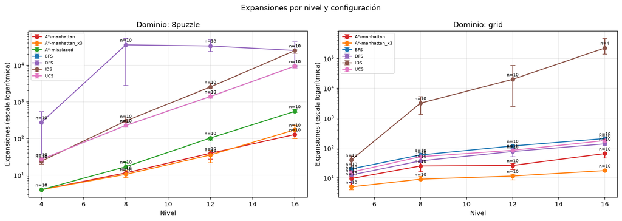

```python
res = leer("resumen_parte1.csv")
filas = [f for f in res if f["level"] == "16"]
for f in filas:
    for c in ("expansions_med", "max_frontier_med", "cost_med"):
        f[c] = f"{float(f[c]):,.0f}".replace(",", " ") if f[c] not in ("", "None") else "—"
    f["seconds_med"] = f"{float(f['seconds_med'])*1000:.1f}" if f["seconds_med"] not in ("", "None") else "—"
tabla(filas, ["domain", "config", "solved", "timeouts", "cost_med", "expansions_med", "max_frontier_med", "seconds_med"],
      ["dominio", "algoritmo", "resueltas", "timeouts", "costo", "expansiones", "frontera máx.", "tiempo (ms)"])
display(Image(filename="fig/expansiones_vs_nivel.png"))
```

En el 8-puzzle, BFS, UCS e IDS crecen en línea recta en escala logarítmica, es decir, de forma **exponencial**. A* con Manhattan expande unas 100 veces menos. En la grilla, IDS se dispara: en 16×16 hizo timeout en 6 de 10 corridas.

### 2.1 UCS = A* y por qué BFS falla con costos no uniformes

```python
opt = leer("optimalidad.csv")
iguales = sum(f["astar_admisible_igual_ucs"] == "True" for f in opt)
bfs_grilla = [f for f in opt if f["domain"] == "grid" and float(f["bfs_sobrecosto"]) > 0]
print(f"A* admisible devuelve el mismo costo que UCS en {iguales}/80 instancias")
print(f"BFS es subóptimo en {len(bfs_grilla)}/40 grillas y en 0/40 puzzles (costo uniforme)")
texto = (R / "bfs_suboptimo.md").read_text(encoding="utf-8")
display(Markdown(texto[texto.index("## La instancia"):]))
```

```
A* admisible devuelve el mismo costo que UCS en 80/80 instancias
BFS es subóptimo en 33/40 grillas y en 0/40 puzzles (costo uniforme)
```

La instancia que mostramos: `grid-12-09`

BFS usa 11 pasos y cuesta 32; UCS usa 11 pasos y cuesta 11 (+21, 191 % más caro). BFS minimiza el número de pasos y no mira el terreno; UCS minimiza el costo acumulado. Costos al entrar: `.`=1, `,`=3, `~`=8.

**BFS** — `DDDDDDRRRRR`

```
. , , . . . , . . , , .
. , ~ , , , . . . . . ,
. ~ . S . . . ~ . , . .
. . , * . . . . . . . .
. . . * . , . . , . . .
. , . * ~ , . . . ~ , ~
~ . ~ * . , , , . . . ~
. ~ . * . . , ~ . . . ~
. . . * * * * * G , . ,
, . , . . . ~ . , . . .
. ~ . . . ~ , . . . , .
. , . . . . . . , ~ ~ .
```

**UCS (óptimo)** — `DRRRDDRRDDD`

```
. , , . . . , . . , , .
. , ~ , , , . . . . . ,
. ~ . S . . . ~ . , . .
. . , * * * * . . . . .
. . . . . , * . , . . .
. , . ~ ~ , * * * ~ , ~
~ . ~ ~ . , , , * . . ~
. ~ . ~ . . , ~ * . . ~
. . . . . . . . G , . ,
, . , . . . ~ . , . . .
. ~ . . . ~ , . . . , .
. , . . . . . . , ~ ~ .
```

BFS minimiza **pasos**, no costo: en `grid-12-09` sus 11 pasos cruzan agua (`~` = 8). Su garantía de optimalidad tiene una condición, que los costos sean uniformes, y aquí no se cumple.

### 2.2 Dominancia de Manhattan sobre misplaced

```
Manhattan expandió igual o menos que misplaced en 40/40 instancias
```

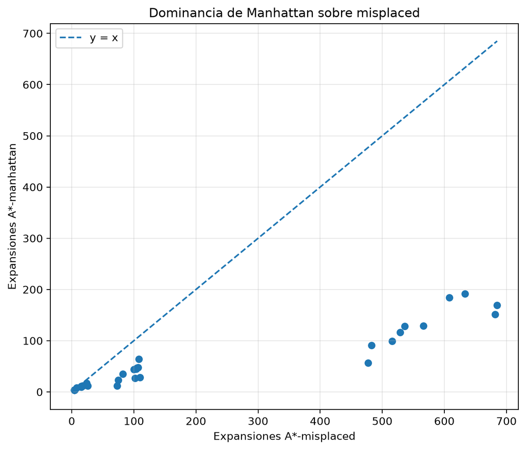

```python
dom = leer("dominancia.csv")
print(f"Manhattan expandió igual o menos que misplaced en {sum(f['ok']=='True' for f in dom)}/40 instancias")
display(Image(filename="fig/dominancia.png", width=520))
```

### 2.3 Romper la admisibilidad: h × 3

Se reportan **los dos números**: cuánto se acelera la búsqueda y cuánto empeora la solución.

```
Soluciones subóptimas con h×3: 20/80
Peor caso: 8puzzle-16-07: costo 24 vs óptimo 16, 261 expansiones vs 99
```

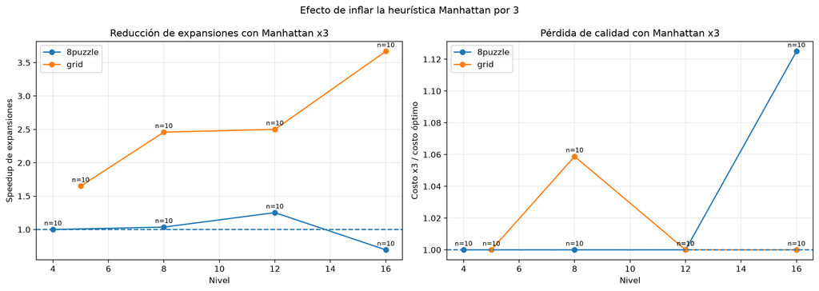

```python
x3 = leer("inflado_x3.csv")
sub = [f for f in x3 if float(f["ratio_costo"]) > 1]
peor = max(x3, key=lambda f: float(f["ratio_costo"]))
print(f"Soluciones subóptimas con h×3: {len(sub)}/80")
print(f"Peor caso: {peor['instance']}: costo {peor['cost_x3']} vs óptimo {peor['cost_opt']}, "
      f"{peor['exp_x3']} expansiones vs {peor['exp_manhattan']}")
display(Image(filename="fig/inflado_x3.png"))
```

En la grilla, h×3 acelera hasta 3,7× con pérdidas de calidad moderadas. En el 8-puzzle de profundidad 16 expande **más** y pierde optimalidad en 6 de 10 instancias. Inflar la heurística cambia la garantía por velocidad, y esa velocidad no siempre llega.

### 2.4 Factor de ramificación efectivo b*

| profundidad | configuración | b* (mediana) |
| --- | --- | --- |
| 8 | UCS | 1.78 |
| 8 | A*-misplaced | 1.17 |
| 8 | A*-manhattan | 1.08 |
| 8 | A*-manhattan_x3 | 1.06 |
| 12 | UCS | 1.70 |
| 12 | A*-misplaced | 1.31 |
| 12 | A*-manhattan | 1.17 |
| 12 | A*-manhattan_x3 | 1.16 |
| 16 | UCS | 1.67 |
| 16 | A*-misplaced | 1.37 |
| 16 | A*-manhattan | 1.22 |
| 16 | A*-manhattan_x3 | 1.18 |

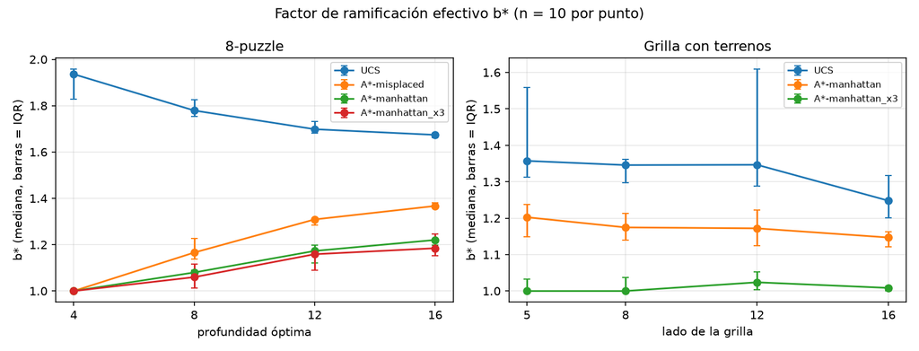

```python
b = leer("branching_resumen.csv")
tabla([dict(f, b_star_median=f"{float(f['b_star_median']):.2f}") for f in b if f["domain"] == "8puzzle" and f["level"] != "4"],
      ["level", "config", "b_star_median"], ["profundidad", "configuración", "b* (mediana)"])
display(Image(filename="fig/branching.png"))
```

## 3. Parte 2: el duelo

### 3.1 Cómo juzgamos al LLM

**Nunca le preguntamos al modelo si su respuesta es correcta.** Nuestro validador camina el camino paso a paso, recalcula el costo y lo compara con el óptimo de nuestro A*. Este es un ejemplo real de la corrida oficial:

```python
import validador, dominios, duelo_llm
llm = {f["instance"]: f for f in leer("llm_respuestas.csv")}
llamadas = [json.loads(l) for l in open(R / "llm_calls.jsonl", encoding="utf-8")]
ejemplo = next(l for l in llamadas if l["instance"] == "grid-5-00" and l.get("system") == "llm")
print("PROMPT (exacto del curso):\n" + ejemplo["prompt"])
print("RESPUESTA DEL MODELO:\n" + ejemplo["text"].strip()[-300:])
_, _, grid = dominios.buscar("grid-5-00")
print("\nVEREDICTO:", validador.validar_texto("grid", grid, ejemplo["text"]))
```

```
PROMPT (exacto del curso):
Find the minimum-cost path from S to G.
Terrain costs: '.' = 1, ',' = 3, '~' = 8.
Move up/down/left/right only.
Grid:
. S . . .
. . ~ ~ ~
~ . . , G
. ~ ~ , .
. , ~ . .

Reply with the path as a sequence of moves (U/D/L/R) and its total cost.
Format your final answer as two lines:
PATH: <letters, no separators>
COST: <integer>

RESPUESTA DEL MODELO:
t = 13 + 1 = 14)
   - Move right to (2, 4) (cost = 14 + 3 = 17)
   - Move right to (3, 4) (cost = 17 + 1 = 18)
   - Move right to (4, 4) (cost = 18 + 1 = 19)

   Path: RRRRDRRR
   Cost: 19

After analyzing all possible paths, the minimum cost path from S to G is found to be:

PATH: RRRRDRRR
COST: 19

VEREDICTO: Veredicto(category='illegal', reason='paso 4: se sale del tablero con R', path='RRRRDRRR', reported_cost=19, checker_cost=None, optimal_cost=None, suboptimal=False, wrong_cost=False, tolerant=False)
```

### 3.2 Brazo LLM: 0 de 80

| dominio | nivel | ilegal | subóptima | costo mal | mal formada | no termina | correcta |
| --- | --- | --- | --- | --- | --- | --- | --- |
| 8puzzle | 4 | 9 | 0 | 0 | 0 | 1 | 0 |
| 8puzzle | 8 | 9 | 0 | 0 | 0 | 1 | 0 |
| 8puzzle | 12 | 5 | 0 | 0 | 0 | 5 | 0 |
| 8puzzle | 16 | 9 | 0 | 0 | 0 | 1 | 0 |
| grid | 5 | 8 | 0 | 0 | 0 | 2 | 0 |
| grid | 8 | 4 | 0 | 0 | 1 | 5 | 0 |
| grid | 12 | 1 | 0 | 0 | 2 | 7 | 0 |
| grid | 16 | 0 | 0 | 0 | 0 | 10 | 0 |

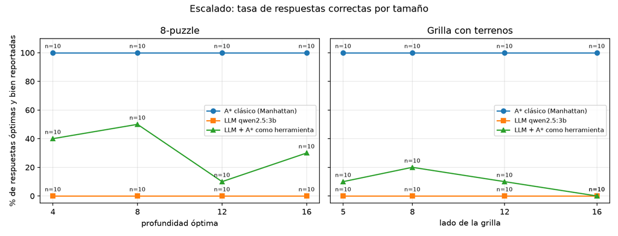

```python
fallas = leer("llm_fallas_por_nivel.csv")
tabla(fallas, ["domain", "level", "illegal", "suboptimal", "wrong_cost", "malformed", "no_termina", "correct"],
      ["dominio", "nivel", "ilegal", "subóptima", "costo mal", "mal formada", "no termina", "correcta"])
display(Image(filename="fig/escalado_optimalidad.png"))
```

El modelo no llegó a ser subóptimo ni a reportar mal un costo, porque **no produjo ni un camino legal**. En la grilla, las respuestas que no terminan pasan de 2/10 a 10/10 al crecer el tamaño.

**¿"No termina" es un error nuestro?** No. Repetimos en streaming las llamadas que Ollama cortó con HTTP 500, y Ollama dio el motivo:

```python
diag = leer("diagnostico_500.csv")
tabla(diag, ["system", "instance", "motivo", "tokens_streaming"], ["brazo", "instancia", "motivo", "tokens"])
ej = next(f for f in diag if "repeat" in f["motivo"])
print("Final del texto que el modelo estaba generando:", repr(ej["final_del_texto"]))
```

| brazo | instancia | motivo | tokens |
| --- | --- | --- | --- |
| llm | 8puzzle-4-03 | terminó (stop) | 128 |
| llm | grid-12-00 | prediction aborted, token repeat limit reached | 497 |
| llm | grid-12-05 | lo cortamos nosotros: seguía generando (1915 tokens) | 1915 |
| llm | grid-16-01 | prediction aborted, token repeat limit reached | 550 |
| llm | grid-16-02 | lo cortamos nosotros: seguía generando (1911 tokens) | 1911 |
| llm | grid-16-04 | lo cortamos nosotros: seguía generando (1909 tokens) | 1909 |
| llm | grid-16-05 | lo cortamos nosotros: seguía generando (1910 tokens) | 1910 |
| llm | grid-16-06 | lo cortamos nosotros: seguía generando (1908 tokens) | 1908 |
| llm | grid-8-01 | terminó (stop) | 215 |
| tool | grid-12-07 | prediction aborted, token repeat limit reached | 124 |
| tool | grid-12-09 | prediction aborted, token repeat limit reached | 144 |
| tool | grid-16-00 | prediction aborted, token repeat limit reached | 126 |
| tool | grid-16-01 | prediction aborted, token repeat limit reached | 132 |
| tool | grid-16-03 | prediction aborted, token repeat limit reached | 135 |
| tool | grid-16-05 | terminó (stop) | 324 |

```
Final del texto que el modelo estaba generando: 'RRRRRRRRRRRRRRRRRRRRRRRRRRRRRRRRRRRRRRRRRRRRRRRRRRRRRRRRRRRRRRRRRRRRRRRRRRRRRRRR'
```

El modelo repite el mismo token sin parar, y Ollama lo detiene con *"token repeat limit reached"*. Solo 4 llamadas se cortaron sin generar ningún token; esas fueron fallas del servidor y se repitieron. Todo está en `results/auditoria_*.csv` y en `DECISION_NOTES.md`.

### 3.3 Reproducibilidad: 5 llamadas idénticas, sin caché

```python
for archivo in ["reproducibilidad_clasica.csv", "llm_reproducibilidad_grid-8-00.csv",
                "llm_reproducibilidad_grid-5-00.csv", "herramienta_reproducibilidad_grid-5-00.csv"]:
    filas = leer(archivo)
    if "modo" in filas[0]:
        filas = [f for f in filas if f["modo"] == "identicas_t0_s0"]
    caminos = [(f.get("path") or "—", f.get("reported_cost") or f.get("cost") or "—") for f in filas]
    print(f"{archivo:<45} {filas[0]['respuestas_distintas']} distinta(s): {caminos}")
```

```
reproducibilidad_clasica.csv                  1 distinta(s): [('RDRDDDRRR', '13'), ('RDRDDDRRR', '13'), ('RDRDDDRRR', '13'), ('RDRDDDRRR', '13'), ('RDRDDDRRR', '13')]
llm_reproducibilidad_grid-8-00.csv            1 distinta(s): [('—', '—'), ('—', '—'), ('—', '—'), ('—', '—'), ('—', '—')]
llm_reproducibilidad_grid-5-00.csv            3 distinta(s): [('RRRRURUR', '30'), ('—', '—'), ('RRRRDRDR', '27'), ('—', '—'), ('RRRRDRDR', '27')]
herramienta_reproducibilidad_grid-5-00.csv    1 distinta(s): [('SLURR', '24'), ('SLURR', '24'), ('SLURR', '24'), ('SLURR', '24'), ('SLURR', '24')]
```

A* siempre da lo mismo. El LLM, **con temperatura 0 y la misma semilla**, dio 3 resultados distintos en `grid-5-00`. "Temperatura 0" no garantiza reproducibilidad en nuestra máquina.

### 3.4 LLM + A* como herramienta: 17 de 80

| caso | n | correctas |
| --- | --- | --- |
| copió la instancia exacta | 19 | 16 |
| copió la instancia con errores | 22 | 1 |
| formato que no se puede leer | 18 | 0 |
| no llamó a la herramienta | 21 | 0 |

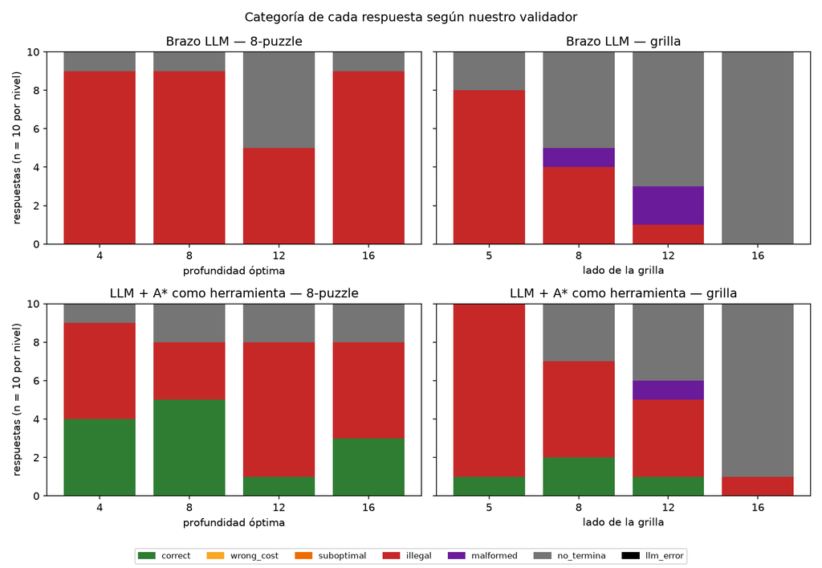

```python
h = leer("herramienta_respuestas.csv")
grupos = {"copió la instancia exacta": [f for f in h if f["tool_args_match"] == "True"],
          "copió la instancia con errores": [f for f in h if f["tool_args_match"] == "False"],
          "formato que no se puede leer": [f for f in h if f["tool_called"] == "True" and f["tool_args_match"] == ""],
          "no llamó a la herramienta": [f for f in h if f["tool_called"] == "False"]}
tabla([{"caso": k, "n": len(v), "correctas": sum(f["category"] == "correct" for f in v)} for k, v in grupos.items()],
      ["caso", "n", "correctas"])
display(Image(filename="fig/fallas_llm.png"))
```

Con el problema bien copiado, el resultado es casi siempre óptimo (16/19). El cuello de botella dejó de ser **buscar** y pasó a ser **transcribir la instancia**, y eso empeora con el tamaño.

## 4. Scorecard

```python
texto = (RAIZ / "REPORT.md").read_text(encoding="utf-8")
display(Markdown(texto[texto.index("| Eje |"):texto.index("## 3. Parte 1")]))
```

| Eje | Clásico (A*-Manhattan) | LLM (`qwen2.5:3b`) | LLM + A* como herramienta | Evidencia |
| --- | --- | --- | --- | --- |
| 1 Corrección | **80/80** óptimas | **0/80** | **17/80** | `results/scorecard.csv` |
| 2 Garantía | Costo mínimo **si** *h* es admisible; nada sobre el tiempo. Con *h*×3 la garantía se pierde (20/80 subóptimas) | Ninguna: 0/80 aquí no dice nada sobre la instancia 81 | Óptimo **solo si** el modelo copia bien la instancia y la respuesta. Lo comprueba nuestro validador, no el sistema | §3.1, §4.3 |
| 3 Costo (mediana) | 23,5 expansiones | 204 tokens | 682 tokens + una búsqueda A* (23,5 expansiones de mediana) | `results/scorecard.csv` |
| 4 Latencia (mediana / p95) | 0,0004 s / 0,002 s | 8,4 s / 302 s | 9,0 s / 302 s | `results/*_respuestas.csv` |
| 5 Reproducibilidad (5 llamadas idénticas) | 1 resultado distinto | `grid-8-00`: 1 (5 bucles); `grid-5-00`: **3 distintos** con temperatura 0 | `grid-5-00`: 1 (la misma respuesta ilegal 5 veces) | `results/*reproducibilidad*.csv` |
| 6 Escalado | 100 % en los 4 tamaños | 0 % en todos; en la grilla, los bucles pasan de 2/10 a 10/10 | 8-puzzle: 10–50 %; grilla: 10–20 % y **0 %** en 16×16 | `fig/escalado_optimalidad.png` |
| 7 Interpretabilidad | Camino + costo, verificables | Texto sin justificación verificable; solo el camino se puede revisar | Camino de A*, verificable si se copió bien | — |
| 8 Modo de falla | Solo IDS hace timeout (6/40, todas en grilla 16×16); A* nunca | Ilegal y seguro de sí (45), no termina (32), mal formado (3) | No llama a la herramienta (21), copia mal la instancia (22) o la envía en un formato que no se puede leer (18) | `fig/fallas_llm.png` |

## 5. Dónde pudimos ser injustos y qué no podemos afirmar

- Usamos heurísticas conocidas frente a un prompt escrito una sola vez y nunca ajustado.
- Es un modelo de 3B: 0/80 no dice nada de modelos grandes ni de grillas de 20×20.
- El banco es pequeño y no tiene paredes, lo que favorece a los algoritmos clásicos.
- La latencia del LLM incluye nuestro límite de 300 s y tramos en que la GPU bajó de velocidad.
- Con 10 instancias por punto, una o dos respuestas más o menos por nivel son ruido.

## 6. Conclusiones y análisis final

1. **Las garantías se cumplen, pero con sus condiciones.** A* con heurística admisible fue óptimo en 80/80 instancias, y BFS solo con costos uniformes: falló en 33/40 grillas. Al inflar la heurística se pierde la garantía, tal como dice la teoría.
2. **Una mejor heurística reduce el trabajo de forma medible.** Manhattan dominó a misplaced en 40/40 instancias y llevó b* de 1,67 (UCS) a 1,22 a profundidad 16.
3. **Un LLM pequeño no sirve como motor de búsqueda.** El modelo resolvió 0 de 80 instancias: o propone caminos ilegales o entra en bucles que no terminan, y empeora con el tamaño.
4. **Como intermediario del solver sí aporta.** Con nuestro A* como herramienta llegó a 17/80, y a 16 de 19 cuando copió bien el problema. La garantía la pone el solver; el modelo solo debe traducir bien.
5. **Lo que medimos también incluye cómo medimos.** Encontramos y documentamos varios problemas propios: corridas concurrentes, un error en nuestra herramienta y una regla de auditoría incompleta. Las corridas descartadas están en `evidencia_descartada/`, porque se califica el experimento, no el veredicto.